# Tutorial 2 — Multi-Site Baseline & Climate Change Analysis

Hurricane Wind Hazard Model for the Caribbean

Published

March 16, 2026

**Prerequisites**

This tutorial assumes you have already worked through Tutorial 1, where the single-site workflow and the main output objects are introduced in more detail.

This tutorial shows how to move from one island to a small group of islands, then compare a stationary baseline with a warmer-climate scenario. The focus is practical: run the model, inspect the annual outputs, and then downscale one site to daily disruption metrics.

## 1 What This Tutorial Covers

By the end, you will be able to:

- run the baseline model for three islands at once
- compare a stationary baseline with a warmer climate scenario
- translate annual scenario differences into daily disruption metrics for one site

```r
library(ipdcstorm)
library(dplyr)
library(ggplot2)
```

## 2 Multi-Site Baseline

We start with the three Dutch Caribbean islands used throughout this package: St. Martin, Saba, and Statia. The setup is the same as in Tutorial 1, except that `targets` now contains three rows instead of one.

```r
seed <- 123L
simulation_years <- 500L

ibtracs_demo <- system.file(
  "extdata",
  "ibtracs_demo.csv",
  package = "ipdcstorm"
)

targets <- data.frame(
  name = c("St_Martin", "Saba", "Statia"),
  lat = c(18.0708, 17.6350, 17.4890),
  lon = c(-63.0501, -63.2300, -62.9740)
)

cfg_baseline <- make_hazard_cfg(
  data_path = ibtracs_demo,
  historical_start_year = 1970L,
  search_radius_km = 800,
  simulation_years = simulation_years,
  climate = make_climate_cfg(scenario = "stationary")
)
```

```r
out_baseline <- run_hazard_model(
  cfg = cfg_baseline,
  targets = targets,
  seed = seed,
  verbose = FALSE
)
```

The `rates` table is the historical calibration result: mean annual site-level rates for tropical storms and hurricanes at each island.

```r
out_baseline$rates
```

```
#> # A tibble: 6 × 6
#>   location  storm_class lambda n_years prob_annual prob_none
#>   <chr>     <chr>        <dbl>   <int>       <dbl>     <dbl>
#> 1 St_Martin HUR          0.191      47       0.174     0.826
#> 2 St_Martin TS           0.553      47       0.425     0.575
#> 3 Saba      HUR          0.128      47       0.120     0.880
#> 4 Saba      TS           0.511      47       0.400     0.600
#> 5 Statia    HUR          0.149      47       0.138     0.862
#> 6 Statia    TS           0.511      47       0.400     0.600
```

The annual simulation table gives one synthetic season per row. For a quick comparison across islands, we can average the simulated counts and hurricane share by location.

```r
baseline_summary <- out_baseline$sim |>
  group_by(location) |>
  summarise(
    mean_total = mean(n_total, na.rm = TRUE),
    mean_ts = mean(n_ts, na.rm = TRUE),
    mean_hur = mean(n_hur, na.rm = TRUE),
    mean_p_hur = mean(p_hurricane, na.rm = TRUE),
    .groups = "drop"
  )

baseline_summary
```

```
#> # A tibble: 3 × 5
#>   location  mean_total mean_ts mean_hur mean_p_hur
#>   <chr>          <dbl>   <dbl>    <dbl>      <dbl>
#> 1 Saba            1.19   1.02     0.17       0.141
#> 2 St_Martin       1.01   0.814    0.194      0.186
#> 3 Statia          1.25   1.09     0.16       0.137
```

| Column | Description |
| --- | --- |
| `mean_total` | Mean annual number of site-impacting storms with at least tropical-storm strength. |
| `mean_ts` | Mean annual number of tropical-storm events. |
| `mean_hur` | Mean annual number of hurricane events. |
| `mean_p_hur` | Mean simulated fraction of storms that are hurricanes. |

## 3 Climate Change Scenarios

The climate extension changes the annual simulation in two SST-driven ways. First, warming can scale the total number of storms up or down through a rate effect. Second, warming can shift the storm mix toward a larger hurricane fraction through an intensity effect.

In this model, both effects are driven by a scalar `delta_sst`: the Main Development Region sea-surface temperature change, in °C, relative to a 1991-2020 baseline. That keeps the workflow simple for scenario testing: you can either use a named scenario helper or supply a direct warming value yourself.

We will compare a stationary baseline (`delta_sst = 0`) with a hypothetical warmer climate using `delta_sst = 1.5`. That is a clean side-by-side example for understanding the direction and size of the climate response.

```r
sst_scenario_info() |>
  filter(source == "ipcc_ar6") |>
  select(scenario, source, delta_sst_2050, delta_sst_2100)
```

```
#> # A tibble: 3 × 4
#>   scenario source   delta_sst_2050 delta_sst_2100
#>   <chr>    <chr>             <dbl>          <dbl>
#> 1 ssp126   ipcc_ar6            0.3            0.4
#> 2 ssp245   ipcc_ar6            0.5            1
#> 3 ssp585   ipcc_ar6            1              2.5
```

The built-in scenario table is useful for context, but for this tutorial we set the warming directly so the climate signal is explicit in the code.

```r
climate_future <- make_climate_cfg(
  delta_sst = 1.5,
  sensitivity_mode = "fixed"
)

cfg_future <- make_hazard_cfg(
  data_path = ibtracs_demo,
  historical_start_year = 1970L,
  search_radius_km = 800,
  simulation_years = simulation_years,
  climate = climate_future
)
```

```r
out_future <- run_hazard_model(
  cfg = cfg_future,
  targets = targets,
  seed = seed,
  verbose = FALSE
)
```

Now we stack the two annual simulation tables and compute a compact comparison by scenario and island. The summary below reports the mean annual storm count, the tropical-storm and hurricane components, and the mean simulated hurricane fraction.

```r
activity_summary <- bind_rows(
  out_baseline$sim |> mutate(scenario = "Baseline"),
  out_future$sim |> mutate(scenario = "Future (+1.5 C)")
) |>
  group_by(scenario, location) |>
  summarise(
    mean_total = mean(n_total, na.rm = TRUE),
    mean_ts = mean(n_ts, na.rm = TRUE),
    mean_hur = mean(n_hur, na.rm = TRUE),
    mean_p_hur = mean(p_hurricane, na.rm = TRUE),
    .groups = "drop"
  ) |>
  arrange(location, scenario)

activity_summary
```

```
#> # A tibble: 6 × 6
#>   scenario        location  mean_total mean_ts mean_hur mean_p_hur
#>   <chr>           <chr>          <dbl>   <dbl>    <dbl>      <dbl>
#> 1 Baseline        Saba            1.19   1.02     0.17       0.141
#> 2 Future (+1.5 C) Saba            1.24   1.03     0.204      0.168
#> 3 Baseline        St_Martin       1.01   0.814    0.194      0.186
#> 4 Future (+1.5 C) St_Martin       1.15   0.91     0.238      0.220
#> 5 Baseline        Statia          1.25   1.09     0.16       0.137
#> 6 Future (+1.5 C) Statia          1.31   1.11     0.202      0.162
```

| Column | Description |
| --- | --- |
| `scenario` | Baseline or future climate label used for the comparison. |
| `location` | Target island. |
| `mean_total` | Mean annual storm count under that scenario. |
| `mean_ts` | Mean annual tropical-storm count. |
| `mean_hur` | Mean annual hurricane count. |
| `mean_p_hur` | Mean simulated hurricane fraction. |

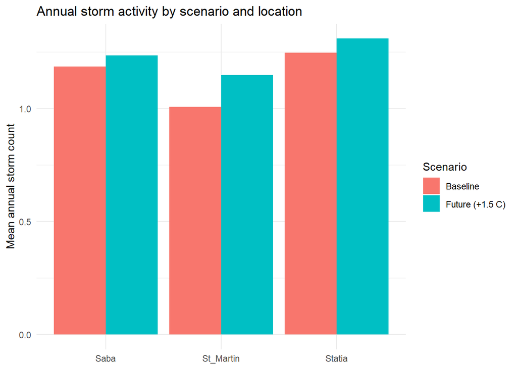

```r
activity_summary |>
  ggplot(aes(x = location, y = mean_total, fill = scenario)) +
  geom_col(position = "dodge") +
  labs(
    x = NULL,
    y = "Mean annual storm count",
    fill = "Scenario",
    title = "Annual storm activity by scenario and location"
  ) +
  theme_minimal(base_size = 11)
```

**Interpreting scenario differences**

These scenario differences are changes in long-run stochastic behavior, not forecasts for any single year. A higher `mean_total` or `mean_p_hur` means the simulated climate state is more active on average, but quiet years still occur.

## 4 Daily Series Comparison

Annual counts are useful for climatology, but many planning questions depend on daily disruption. To illustrate that step, we generate daily hazard-impact series for Saba under the baseline and the warmer scenario.

```r
daily_baseline <- generate_daily_hazard_impact(
  out = out_baseline,
  location = "Saba",
  sim_years = 1:200,
  year0 = 2025,
  gust_factor = 1.25,
  damage = list(method = "intensity"),
  pulse_shape = "cosine",
  scenario = "Baseline",
  seed = 123
)$Saba

daily_future <- generate_daily_hazard_impact(
  out = out_future,
  location = "Saba",
  sim_years = 1:200,
  year0 = 2025,
  gust_factor = 1.25,
  damage = list(method = "intensity"),
  pulse_shape = "cosine",
  scenario = "Future (+1.5 C)",
  seed = 123
)$Saba
```

The combined table lets us compare how often Saba experiences tropical-storm and hurricane days, along with the average annual damage-rate signal over the 200 simulated years.

```r
daily_summary <- bind_rows(daily_baseline, daily_future) |>
  group_by(scenario) |>
  summarise(
    tc_days = sum(wind_kt > 0, na.rm = TRUE),
    ts_days = sum(wind_kt >= 34, na.rm = TRUE),
    hur_days = sum(wind_kt >= 64, na.rm = TRUE),
    mean_annual_damage = sum(damage_rate, na.rm = TRUE) / 200,
    .groups = "drop"
  )

daily_summary
```

```
#> # A tibble: 2 × 5
#>   scenario        tc_days ts_days hur_days mean_annual_damage
#>   <chr>             <int>   <int>    <int>              <dbl>
#> 1 Baseline            887     397      104            0.00260
#> 2 Future (+1.5 C)     931     432      108            0.00238
```

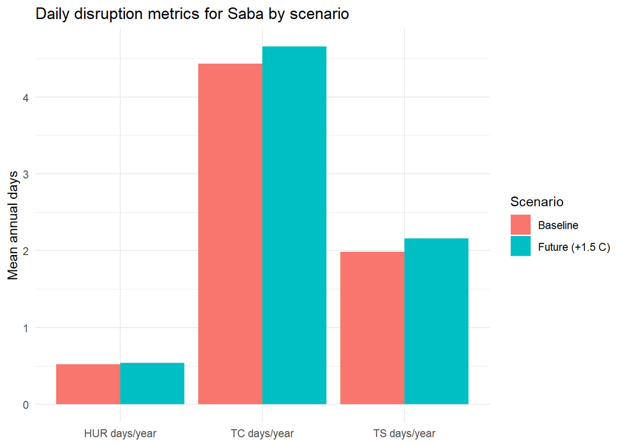

```r
daily_plot_data <- data.frame(
  scenario = rep(daily_summary$scenario, times = 3),
  metric = rep(
    c("TC days/year", "TS days/year", "HUR days/year"),
    each = nrow(daily_summary)
  ),
  value = c(
    daily_summary$tc_days / 200,
    daily_summary$ts_days / 200,
    daily_summary$hur_days / 200
  )
)

daily_plot_data |>
  ggplot(aes(x = metric, y = value, fill = scenario)) +
  geom_col(position = "dodge") +
  labs(
    x = NULL,
    y = "Mean annual days",
    fill = "Scenario",
    title = "Daily disruption metrics for Saba by scenario"
  ) +
  theme_minimal(base_size = 11)
```

| Column | Description |
| --- | --- |
| `tc_days` | Number of simulated days with any tropical-cyclone wind signal (`wind_kt > 0`). |
| `ts_days` | Number of days reaching at least 34 kt. |
| `hur_days` | Number of days reaching at least 64 kt. |
| `mean_annual_damage` | Average annual damage-rate total across the 200 simulated years. |

**About Level 3 perturbation**

The package also supports Level 3 storm perturbation for more exploratory scenario analysis. We do not use it here, so the daily comparison isolates the Level 1 and Level 2 climate effects discussed above.

## 5 Key Parameters

For most climate sensitivity runs, three settings matter most:

| Parameter | What it controls |
| --- | --- |
| `delta_sst` | The imposed MDR SST shift in °C relative to the 1991-2020 baseline. In this tutorial, `delta_sst = 1.5` defines the future climate state directly. |
| `scenario` vs `delta_sst` | Use a named `scenario` when you want a built-in helper tied to a source such as IPCC AR6. Use `delta_sst` when you want a transparent what-if value without committing to one named pathway. |
| `sensitivity_mode` | `"fixed"` keeps the calibrated climate sensitivities unchanged as warming increases. `"linear_shifted"` lets those sensitivities themselves vary with `delta_sst`, which is more exploratory. |

This baseline-versus-scenario pattern is a good starting point for stress testing. Once you are comfortable with the annual and daily outputs, you can expand the same workflow to additional islands or alternative warming assumptions.